# Estimating the Elasticity of Alcohol

AJ Montesa

2024-11-01

# Using Household Expenditure Data

#### **Family Income and Expenditure Survey (FIES)**

The Family Income and Expenditure Survey (FIES) is a nationwide survey of households undertaken every three years by the Philippine Statistics Authority (PSA). It is the main source of data on family income and expenditure, which include among others, levels of consumption by item of expenditure as well as sources of income in cash and in kind. The results of FIES provide information on the levels of living and disparities in income of Filipino families, as well as their spending patterns.

#### **Labor Force Survey (LFS)**

The Labor Force Survey (LFS) is a nationwide survey of households conducted regularly to gather data on the demographic and socio-economic characteristics of the population. It is primarily geared towards the estimation of the levels of employment and unemployment in the country. It is conducted every first month of the quarter in selected areas in the Philippines.

### Variables

| Variable | Description | SummaryStat | 2012 | 2015 | 2018 |
| --- | --- | --- | --- | --- | --- |
| region | Region | # of unique values | 17 | 17 | 17 |
| region_label | Region (labelled) | # of unique values | 17 | 17 | 17 |
| province | Province | # of unique values | 85 | 87 | 87 |
| province_label | Province (labelled) | # of unique values | 85 | 87 | 87 |
| urban | Urban or Rural | categorical | .. | .. | .. |
| sequence_no | Household ID | # of households | 40,145 | 41,544 | 147,717 |
| rfact | Raising Factor / Weight | weighted # of households | 21,413,417 | 22,975,628 | 24,747,174 |
| fsize | Family size | mean value | 4.69 | 4.62 | 4.46 |
| toinc | Annual Household income | mean value | 234,642.77 | 268,024.89 | 313,450.45 |
| ttotex | Annual Household Expenditure | mean value | 192,564.57 | 215,811.90 | 238,751.79 |
| tbeer | Annual household spending on BEER | mean value (non-zero households) | 1,598.86 | 1,557.93 | 1,830.40 |
| qtbeer | Quantity of BEER | proportion (non-zero households) | 29.76% | 25.97% | 31.84% |
| tgin | Annual household spending on GIN | mean value (non-zero households) | 1,025.00 | 1,287.59 | 1,354.33 |
| qtgin | Quantity of GIN | proportion (non-zero households) | 12.53% | 12.72% | 16.23% |
| tcigarette | Annual household spending on CIGARETTES | mean value (non-zero households) | 2,961.20 | 4,723.70 | 6,088.96 |
| qtcigarette | Quantity of CIGARETTES | proportion (non-zero households) | 51.73% | 47.94% | 44.36% |
| hhead_sex | Sex of Household Head | categorical | .. | .. | .. |
| hhead_male | Household Head is MALE | proportion male | 77.55% | 76.97% | 76.39% |
| hhead_age | Age of Household Head | mean value | 50.83 | 51.54 | 50.27 |
| hhead_ms | Marital Status of Household Head | categorical | .. | .. | .. |
| hhead_married | Household Head is MARRIED | proportion married | 75.69% | 74.62% | 75.71% |
| hhead_hgc | Highest Grade Completed of Household Head | categorical | .. | .. | .. |
| hhead_employed | Household Head is EMPLOYED | proportion employed | 77.86% | 78.39% | 77.38% |
| members | Number of household members | mean value | 4.79 | 4.70 | 4.55 |
| members_adult | Number of household members age 18 and older | mean value | 2.97 | 2.98 | 2.90 |
| members_age17below | Number of household members age 17 and younger | mean value | 1.82 | 1.72 | 1.65 |
| members_age05below | Number of household members age 5 and younger | mean value | 0.53 | 0.49 | 0.48 |
| members_male | Number of MALE household members | mean value | 1.88 | 1.89 | 1.76 |
| members_adultmale | Number of MALE household members age 18 and older | mean value | 1.47 | 1.47 | 1.43 |
| members_employed | Number of EMPLOYED household members | mean value | 1.88 | 1.89 | 1.76 |
| members_hgc | Highest grade completed among household members | categorical | .. | .. | .. |

### Generating Unit Values / Prices

```r
hes2012 <- hes2012 %>%
  mutate(uvbeer = tbeer/qtbeer, uvgin = tgin/qtgin, uvcigarette = tcigarette/qtcigarette,
         year = "2012",
         hhead_ms = str_c(hhead_ms)) %>%
  mutate(nonzero_beer = qtbeer>0, nonzero_gin = qtgin>0, nonzero_cigarette = qtcigarette>0)

hes2015 <- hes2015 %>%
  mutate(uvbeer = tbeer/qtbeer, uvgin = tgin/qtgin, uvcigarette = tcigarette/qtcigarette,
         year = "2015",
         hhead_ms = str_c(hhead_ms)) %>%
  mutate(nonzero_beer = qtbeer>0, nonzero_gin = qtgin>0, nonzero_cigarette = qtcigarette>0)

hes2018 <- hes2018 %>%
  mutate(uvbeer = tbeer/qtbeer, uvgin = tgin/qtgin, uvcigarette = tcigarette/qtcigarette,
         year = "2018",
         hhead_ms = str_c(hhead_ms)) %>%
  mutate(nonzero_beer = qtbeer>0, nonzero_gin = qtgin>0, nonzero_cigarette = qtcigarette>0)

hesPooled <- bind_rows(hes2012, hes2015, hes2018) %>%
  left_join(inflation_factors) %>%
  mutate(year = as_factor(year)) %>%
  mutate(toinc_b18 = toinc/inflation_factor, ttotex_b18 = ttotex/inflation_factor,
         tbeer_b18 = tbeer/inflation_factor, tgin_b18 = tgin/inflation_factor, tcigarette_b18 = tcigarette/inflation_factor) %>%
  mutate(uvbeer = tbeer/qtbeer, uvgin = tgin/qtgin, uvcigarette = tcigarette/qtcigarette,
         uvbeer_b18 = tbeer_b18/qtbeer, uvgin_b18 = tgin_b18/qtgin, uvcigarette_b18 = tcigarette_b18/qtcigarette) %>%
  mutate(nonzero_beer = qtbeer>0, nonzero_gin = qtgin>0, nonzero_cigarette = qtcigarette>0)
```

### Exploring the Variables

#### Expenditures

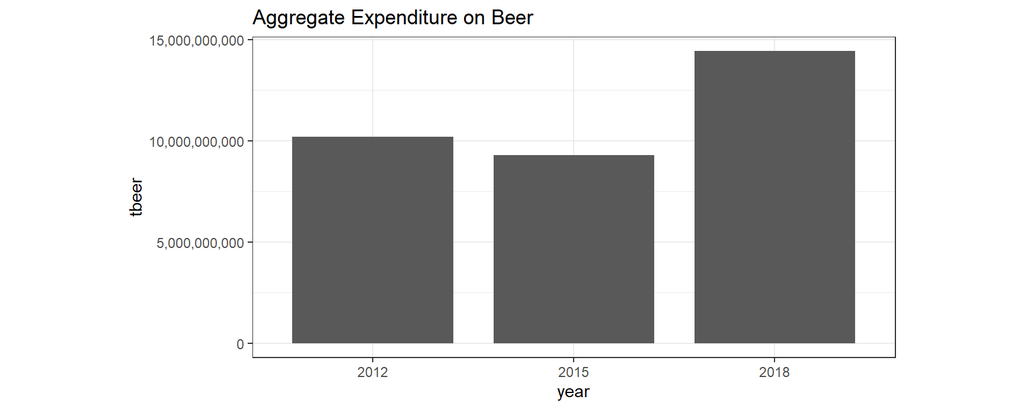

```r
ggplot(data = hesPooled %>% group_by(year) %>% summarize(tbeer = sum(tbeer*rfact, na.rm = TRUE))) +
  geom_col(aes(x = year, y = tbeer), width = 0.8) +
  scale_y_continuous(labels = comma) +
  labs(title = "Aggregate Expenditure on Beer") +
  theme_bw() +
  theme(aspect.ratio = 1/2)
```

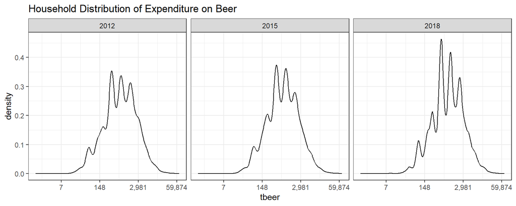

```r
ggplot(data = hesPooled) +
  geom_density(aes(x = tbeer)) +
  facet_wrap(~ year)  +
  scale_x_continuous(trans = "log", labels = comma) +
  labs(title = "Household Distribution of Expenditure on Beer") +
  theme_bw()
```

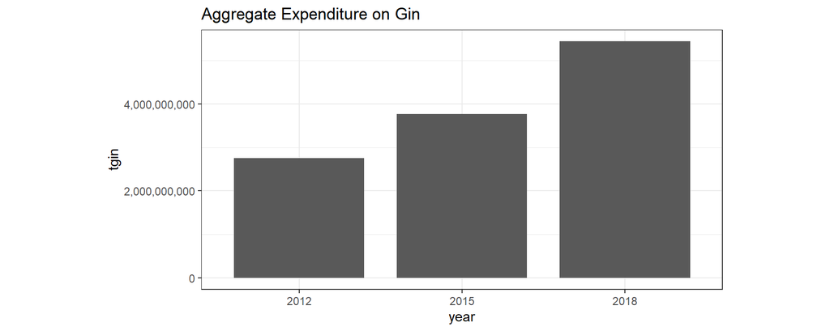

```r
ggplot(data = hesPooled %>% group_by(year) %>% summarize(tgin = sum(tgin*rfact, na.rm = TRUE))) +
  geom_col(aes(x = year, y = tgin), width = 0.8) +
  scale_y_continuous(labels = comma) +
  labs(title = "Aggregate Expenditure on Gin") +
  theme_bw() +
  theme(aspect.ratio = 1/2)
```

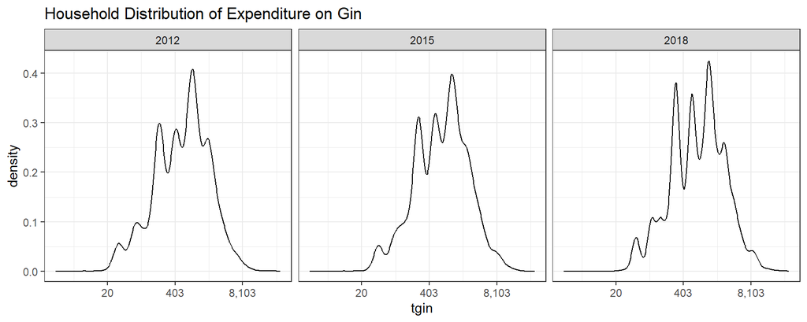

```r
ggplot(data = hesPooled) +
  geom_density(aes(x = tgin)) +
  facet_wrap(~ year) +
  scale_x_continuous(trans = "log", labels = comma) +
  labs(title = "Household Distribution of Expenditure on Gin") +
  theme_bw()
```

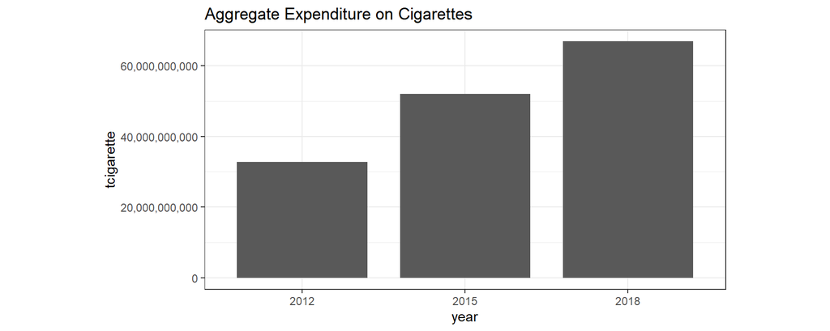

```r
ggplot(data = hesPooled %>% group_by(year) %>% summarize(tcigarette = sum(tcigarette*rfact, na.rm = TRUE))) +
  geom_col(aes(x = year, y = tcigarette), width = 0.8) +
  scale_y_continuous(labels = comma) +
  labs(title = "Aggregate Expenditure on Cigarettes") +
  theme_bw() +
  theme(aspect.ratio = 1/2)
```

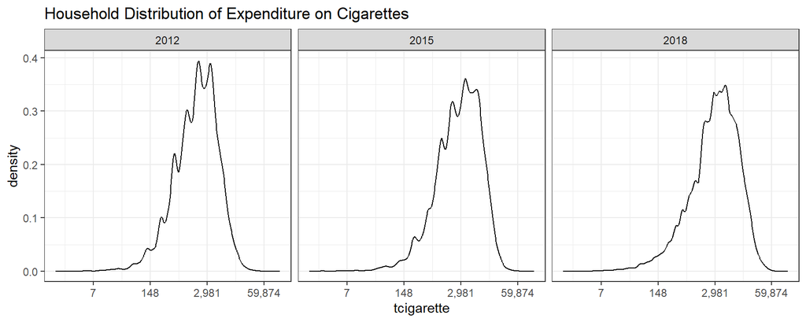

```r
ggplot(data = hesPooled) +
  geom_density(aes(x = tcigarette)) +
  facet_wrap(~ year) +
  scale_x_continuous(trans = "log", labels = comma) +
  labs(title = "Household Distribution of Expenditure on Cigarettes") +
  theme_bw()
```

#### Quantities

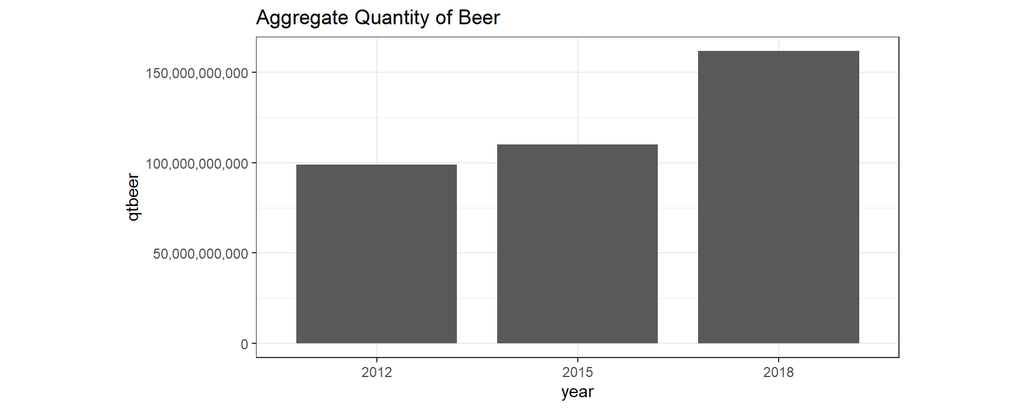

```r
ggplot(data = hesPooled %>% group_by(year) %>% summarize(qtbeer = sum(qtbeer*rfact, na.rm = TRUE))) +
  geom_col(aes(x = year, y = qtbeer), width = 0.8) +
  scale_y_continuous(labels = comma) +
  labs(title = "Aggregate Quantity of Beer") +
  theme_bw() +
  theme(aspect.ratio = 1/2)
```

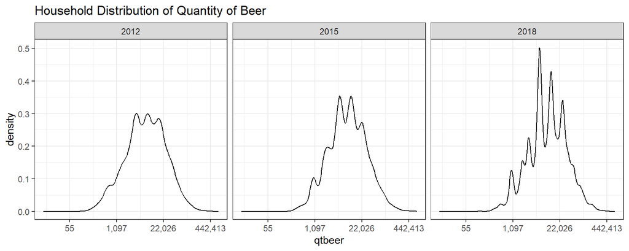

```r
ggplot(data = hesPooled) +
  geom_density(aes(x = qtbeer)) +
  facet_wrap(~ year)  +
  scale_x_continuous(trans = "log", labels = comma) +
  labs(title = "Household Distribution of Quantity of Beer") +
  theme_bw()
```

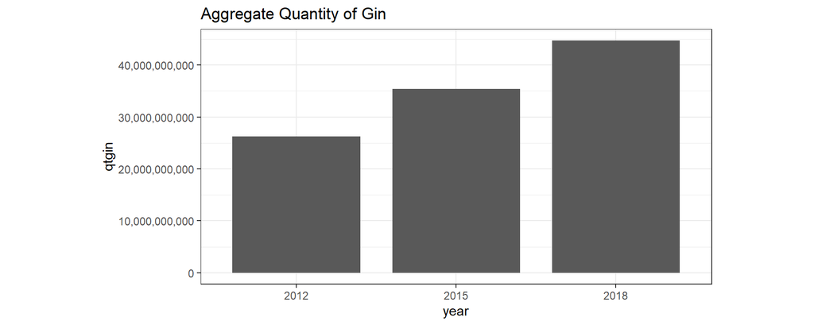

```r
ggplot(data = hesPooled %>% group_by(year) %>% summarize(qtgin = sum(qtgin*rfact, na.rm = TRUE))) +
  geom_col(aes(x = year, y = qtgin), width = 0.8) +
  scale_y_continuous(labels = comma) +
  labs(title = "Aggregate Quantity of Gin") +
  theme_bw() +
  theme(aspect.ratio = 1/2)
```

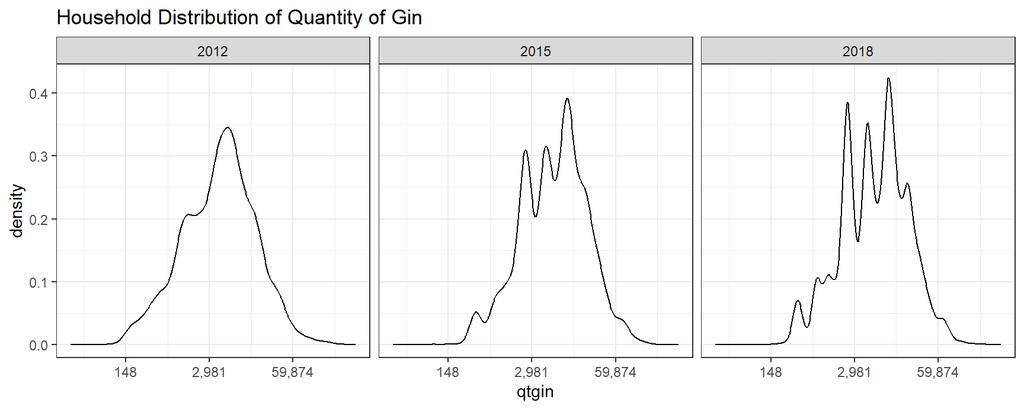

```r
ggplot(data = hesPooled) +
  geom_density(aes(x = qtgin)) +
  facet_wrap(~ year) +
  scale_x_continuous(trans = "log", labels = comma) +
  labs(title = "Household Distribution of Quantity of Gin") +
  theme_bw()
```

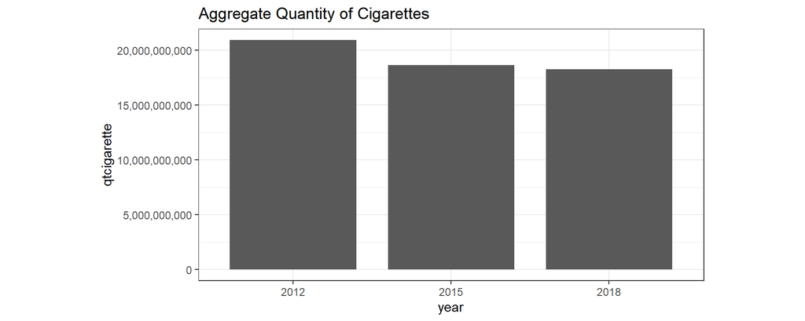

```r
ggplot(data = hesPooled %>% group_by(year) %>% summarize(qtcigarette = sum(qtcigarette*rfact, na.rm = TRUE))) +
  geom_col(aes(x = year, y = qtcigarette), width = 0.8) +
  scale_y_continuous(labels = comma) +
  labs(title = "Aggregate Quantity of Cigarettes") +
  theme_bw() +
  theme(aspect.ratio = 1/2)
```

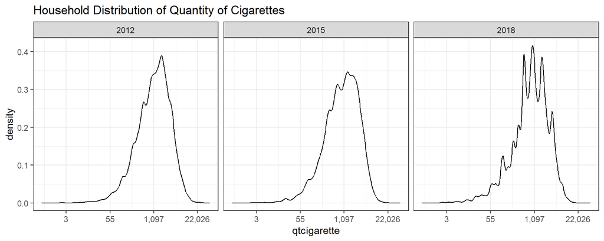

```r
ggplot(data = hesPooled) +
  geom_density(aes(x = qtcigarette)) +
  facet_wrap(~ year) +
  scale_x_continuous(trans = "log", labels = comma) +
  labs(title = "Household Distribution of Quantity of Cigarettes") +
  theme_bw()
```

#### Unit Values

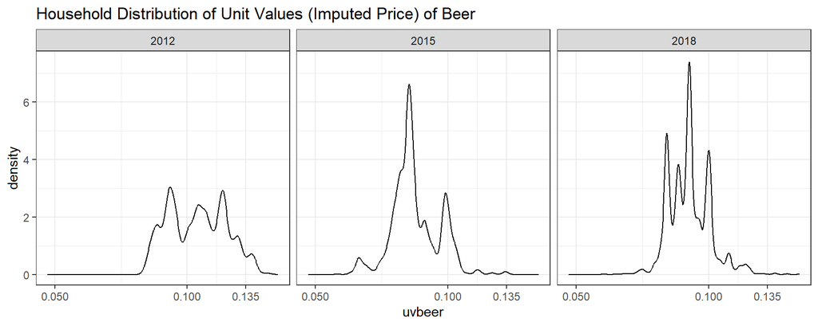

```r
ggplot(data = hesPooled) +
  geom_density(aes(x = uvbeer)) +
  facet_wrap(~ year)  +
  scale_x_continuous(trans = "log", labels = comma) +
  labs(title = "Household Distribution of Unit Values (Imputed Price) of Beer") +
  theme_bw()
```

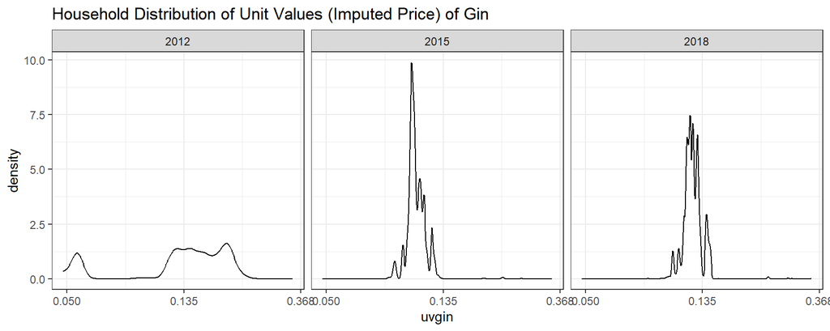

```r
ggplot(data = hesPooled) +
  geom_density(aes(x = uvgin)) +
  facet_wrap(~ year) +
  scale_x_continuous(trans = "log", labels = comma) +
  labs(title = "Household Distribution of Unit Values (Imputed Price) of Gin") +
  theme_bw()
```

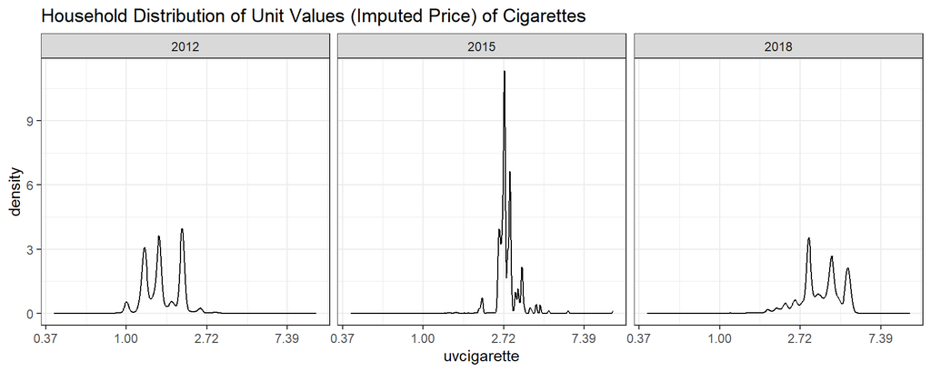

```r
ggplot(data = hesPooled) +
  geom_density(aes(x = uvcigarette)) +
  facet_wrap(~ year) +
  scale_x_continuous(trans = "log", labels = comma) +
  labs(title = "Household Distribution of Unit Values (Imputed Price) of Cigarettes") +
  theme_bw()
```

#### Quantities vs Unit Values

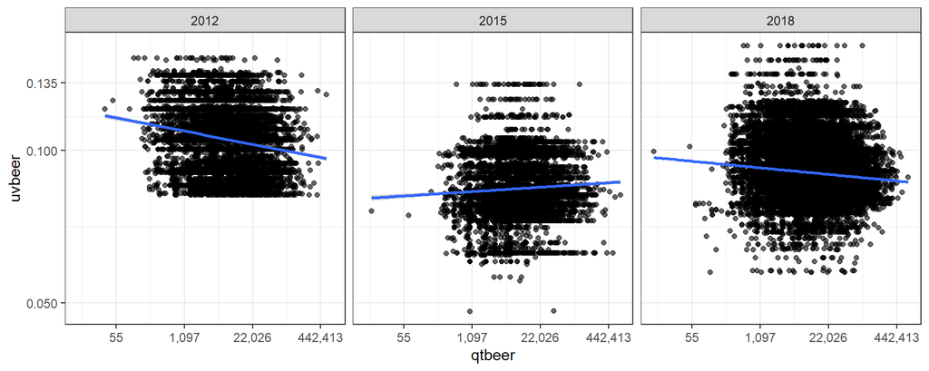

```r
ggplot(data = hesPooled, aes(x = qtbeer, y = uvbeer)) +
  geom_point(alpha = 0.6) +
  geom_smooth(method = "lm") +
  facet_wrap(~ year)  +
  scale_x_continuous(trans = "log", labels = comma) +
  scale_y_continuous(trans = "log", labels = comma) +
  theme_bw()
```

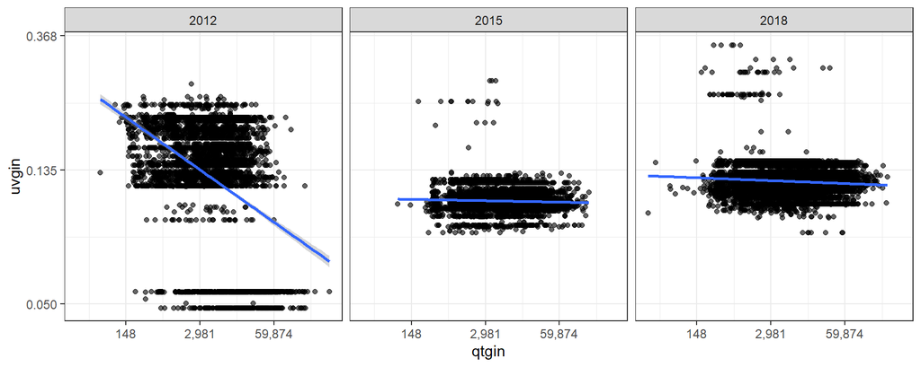

```r
ggplot(data = hesPooled, aes(x = qtgin, y = uvgin)) +
  geom_point(alpha = 0.6) +
  geom_smooth(method = "lm") +
  facet_wrap(~ year)  +
  scale_x_continuous(trans = "log", labels = comma) +
  scale_y_continuous(trans = "log", labels = comma) +
  theme_bw()
```

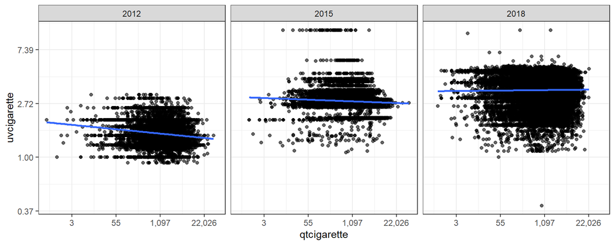

```r
ggplot(data = hesPooled, aes(x = qtcigarette, y = uvcigarette)) +
  geom_point(alpha = 0.6) +
  geom_smooth(method = "lm") +
  facet_wrap(~ year)  +
  scale_x_continuous(trans = "log", labels = comma) +
  scale_y_continuous(trans = "log", labels = comma) +
  theme_bw()
```

# Modeling Elasticity

## Ordinary Least Squares

### Beer

```r
ols_beer <- log(qtbeer) ~ log(uvbeer) + log(toinc) + hhead_male + hhead_age + hhead_married + hhead_employed + members + I(members_adultmale/members) + region_label + urban

ols_beerPool <- log(qtbeer) ~ log(uvbeer_b18) + log(toinc_b18) + hhead_male + hhead_age + hhead_married + hhead_employed + members + I(members_adultmale/members) + region_label + urban + factor(year)

ols_beerPoolInteraction <- log(qtbeer) ~ log(uvbeer_b18)*year + log(toinc_b18) + hhead_male + hhead_age + hhead_married + hhead_employed + members + I(members_adultmale/members) + region_label + urban


ols_b2012 <- lm(formula = ols_beer, data = hes2012, weights = rfact)

ols_b2015 <- lm(formula = ols_beer, data = hes2015, weights = rfact)

ols_b2018 <- lm(formula = ols_beer, data = hes2018, weights = rfact)

ols_bPool <- lm(ols_beerPool, data = hesPooled, weights = rfact)

ols_bInt <- lm(ols_beerPoolInteraction, data = hesPooled, weights = rfact)

stargazer(ols_b2012, ols_b2015, ols_b2018, ols_bPool, ols_bInt,
          type="html",
          column.labels = c("2012", "2015", "2018", "Pooled", "Pooled, With Year Interaction"))
```

|  | *Dependent variable:* |  |  |  |  |
| --- | --- | --- | --- | --- | --- |
|  | log(qtbeer) |  |  |  |  |
|  | 2012 | 2015 | 2018 | Pooled | Pooled, With Year Interaction |
|  | (1) | (2) | (3) | (4) | (5) |
| log(uvbeer) | -1.200*** | 1.088*** | -0.574*** |  |  |
|  | (0.087) | (0.107) | (0.057) |  |  |
| log(toinc) | 0.475*** | 0.432*** | 0.427*** |  |  |
|  | (0.017) | (0.018) | (0.009) |  |  |
| log(uvbeer_b18) |  |  |  | -0.486*** | -1.032*** |
|  |  |  |  | (0.036) | (0.053) |
| year2015 |  |  |  |  | 3.533*** |
|  |  |  |  |  | (0.187) |
| year2018 |  |  |  |  | 0.845*** |
|  |  |  |  |  | (0.204) |
| log(toinc_b18) |  |  |  | 0.448*** | 0.445*** |
|  |  |  |  | (0.007) | (0.007) |
| hhead_male | 0.235*** | 0.181*** | 0.084*** | 0.154*** | 0.153*** |
|  | (0.040) | (0.041) | (0.018) | (0.016) | (0.016) |
| hhead_age | -0.004*** | -0.004*** | -0.002*** | -0.003*** | -0.003*** |
|  | (0.001) | (0.001) | (0.0005) | (0.0004) | (0.0004) |
| hhead_married | -0.205*** | -0.101*** | -0.085*** | -0.119*** | -0.119*** |
|  | (0.038) | (0.037) | (0.017) | (0.015) | (0.015) |
| hhead_employed | 0.083*** | 0.018 | 0.078*** | 0.061*** | 0.059*** |
|  | (0.032) | (0.033) | (0.016) | (0.013) | (0.013) |
| members | 0.010* | 0.016*** | 0.017*** | 0.014*** | 0.014*** |
|  | (0.006) | (0.006) | (0.003) | (0.002) | (0.002) |
| I(members_adultmale/members) | 0.452*** | 0.397*** | 0.496*** | 0.453*** | 0.450*** |
|  | (0.065) | (0.066) | (0.031) | (0.026) | (0.026) |
| region_label14 Cordillera Administrative Region | -0.502*** | -0.545*** | -1.139*** | -0.732*** | -0.744*** |
|  | (0.100) | (0.109) | (0.055) | (0.043) | (0.043) |
| region_label01 Ilocos Region | 0.043 | -0.128** | -0.185*** | -0.075*** | -0.102*** |
|  | (0.067) | (0.064) | (0.032) | (0.026) | (0.026) |
| region_label02 Cagayan Valley | 0.193*** | 0.113 | -0.078** | 0.099*** | 0.076** |
|  | (0.073) | (0.072) | (0.038) | (0.030) | (0.030) |
| region_label03 Central Luzon | 0.094** | -0.253*** | -0.022 | -0.059*** | -0.071*** |
|  | (0.045) | (0.043) | (0.019) | (0.017) | (0.017) |
| region_label04 CALABARZON | -0.072* | -0.089** | 0.029 | -0.021 | -0.032* |
|  | (0.043) | (0.044) | (0.020) | (0.017) | (0.017) |
| region_label17 MIMAROPA | 0.048 | -0.237** | -0.426*** | -0.245*** | -0.253*** |
|  | (0.102) | (0.094) | (0.044) | (0.038) | (0.038) |
| region_label05 Bicol Region | -0.346*** | -0.410*** | -0.537*** | -0.458*** | -0.443*** |
|  | (0.073) | (0.069) | (0.033) | (0.028) | (0.028) |
| region_label06 Western Visayas | 0.124** | 0.113** | -0.090*** | -0.005 | 0.020 |
|  | (0.052) | (0.051) | (0.024) | (0.020) | (0.020) |
| region_label07 Central Visayas | 0.049 | -0.317*** | -0.273*** | -0.148*** | -0.183*** |
|  | (0.045) | (0.046) | (0.022) | (0.018) | (0.018) |
| region_label08 Eastern Visayas | -0.270*** | -0.183*** | -0.276*** | -0.246*** | -0.241*** |
|  | (0.067) | (0.063) | (0.030) | (0.026) | (0.026) |
| region_label09 Zamboanga Peninsula | -0.371*** | -0.203*** | -0.302*** | -0.327*** | -0.321*** |
|  | (0.067) | (0.069) | (0.034) | (0.028) | (0.028) |
| region_label10 Northern Mindanao | -0.131** | -0.362*** | -0.284*** | -0.244*** | -0.259*** |
|  | (0.057) | (0.062) | (0.029) | (0.024) | (0.024) |
| region_label11 Davao Region | -0.023 | -0.176*** | -0.065** | -0.063*** | -0.089*** |
|  | (0.053) | (0.057) | (0.026) | (0.022) | (0.022) |
| region_label12 SOCCSKSARGEN | 0.013 | 0.389*** | -0.024 | -0.006 | 0.037 |
|  | (0.063) | (0.076) | (0.032) | (0.027) | (0.027) |
| region_label16 CARAGA Region | -0.211*** | -0.166** | -0.196*** | -0.251*** | -0.223*** |
|  | (0.074) | (0.081) | (0.039) | (0.031) | (0.031) |
| region_label15 Autonomous Region in Muslim Mindanao | -0.314* | -0.876*** | -0.796*** | -0.581*** | -0.635*** |
|  | (0.174) | (0.217) | (0.138) | (0.087) | (0.087) |
| urbanUrban | 0.245*** | 0.219*** | 0.155*** | 0.201*** | 0.202*** |
|  | (0.028) | (0.029) | (0.013) | (0.011) | (0.011) |
| factor(year)2015 |  |  |  | 0.037** |  |
|  |  |  |  | (0.018) |  |
| factor(year)2018 |  |  |  | 0.117*** |  |
|  |  |  |  | (0.019) |  |
| log(uvbeer_b18):year2015 |  |  |  |  | 1.575*** |
|  |  |  |  |  | (0.084) |
| log(uvbeer_b18):year2018 |  |  |  |  | 0.402*** |
|  |  |  |  |  | (0.090) |
| Constant | 0.138 | 6.308*** | 2.295*** | 2.122*** | 1.096*** |
|  | (0.287) | (0.357) | (0.184) | (0.118) | (0.139) |
| Observations | 11,319 | 10,003 | 44,545 | 65,867 | 65,867 |
| R<sup>2</sup> | 0.149 | 0.129 | 0.124 | 0.134 | 0.139 |
| Adjusted R<sup>2</sup> | 0.147 | 0.126 | 0.123 | 0.134 | 0.138 |
| Residual Std. Error | 28.045 (df = 11293) | 27.542 (df = 9977) | 15.039 (df = 44519) | 20.202 (df = 65839) | 20.147 (df = 65837) |
| F Statistic | 79.173*** (df = 25; 11293) | 58.857*** (df = 25; 9977) | 251.481*** (df = 25; 44519) | 377.743*** (df = 27; 65839) | 365.965*** (df = 29; 65837) |
| *Note:* | p<0.1; p<0.05; p<0.01 |  |  |  |  |

### Gin

```r
ols_gin <- log(qtgin) ~ log(uvgin) + log(toinc) + hhead_male + hhead_age + hhead_married + hhead_employed + members + I(members_adultmale/members) + region_label + urban

ols_ginPool <- log(qtgin) ~ log(uvgin_b18) + log(toinc_b18) + hhead_male + hhead_age + hhead_married + hhead_employed + members + I(members_adultmale/members) + region_label + urban + factor(year)

ols_ginPoolInteraction <- log(qtgin) ~ log(uvgin_b18)*year + log(toinc_b18) + hhead_male + hhead_age + hhead_married + hhead_employed + members + I(members_adultmale/members) + region_label + urban


ols_g2012 <- lm(formula = ols_gin, data = hes2012, weights = rfact)

ols_g2015 <- lm(formula = ols_gin, data = hes2015, weights = rfact)

ols_g2018 <- lm(formula = ols_gin, data = hes2018, weights = rfact)

ols_gPool <- lm(ols_ginPool, data = hesPooled, weights = rfact)

ols_gInt <- lm(ols_ginPoolInteraction, data = hesPooled, weights = rfact)

stargazer(ols_g2012, ols_g2015, ols_g2018, ols_gPool, ols_gInt,
          type="html",
          column.labels = c("2012", "2015", "2018", "Pooled", "Pooled, With Year Interaction"))
```

|  | *Dependent variable:* |  |  |  |  |
| --- | --- | --- | --- | --- | --- |
|  | log(qtgin) |  |  |  |  |
|  | 2012 | 2015 | 2018 | Pooled | Pooled, With Year Interaction |
|  | (1) | (2) | (3) | (4) | (5) |
| log(uvgin) | -1.032*** | -0.191 | 0.029 |  |  |
|  | (0.141) | (0.250) | (0.131) |  |  |
| log(toinc) | 0.299*** | 0.288*** | 0.236*** |  |  |
|  | (0.026) | (0.027) | (0.013) |  |  |
| log(uvgin_b18) |  |  |  | -0.993*** | -1.050*** |
|  |  |  |  | (0.025) | (0.026) |
| year2015 |  |  |  |  | 1.781*** |
|  |  |  |  |  | (0.283) |
| year2018 |  |  |  |  | 1.328*** |
|  |  |  |  |  | (0.312) |
| log(toinc_b18) |  |  |  | 0.277*** | 0.273*** |
|  |  |  |  | (0.010) | (0.010) |
| hhead_male | 0.072 | 0.161*** | 0.148*** | 0.135*** | 0.135*** |
|  | (0.066) | (0.060) | (0.026) | (0.023) | (0.023) |
| hhead_age | 0.0004 | -0.001 | -0.0005 | -0.0003 | -0.0003 |
|  | (0.001) | (0.001) | (0.001) | (0.001) | (0.001) |
| hhead_married | -0.103* | -0.163*** | -0.067*** | -0.115*** | -0.113*** |
|  | (0.055) | (0.050) | (0.023) | (0.020) | (0.020) |
| hhead_employed | 0.148*** | 0.093** | 0.101*** | 0.111*** | 0.110*** |
|  | (0.048) | (0.046) | (0.021) | (0.018) | (0.018) |
| members | 0.015* | 0.018** | 0.022*** | 0.018*** | 0.018*** |
|  | (0.008) | (0.007) | (0.004) | (0.003) | (0.003) |
| I(members_adultmale/members) | 0.446*** | 0.522*** | 0.458*** | 0.463*** | 0.466*** |
|  | (0.092) | (0.087) | (0.040) | (0.034) | (0.034) |
| region_label14 Cordillera Administrative Region | 0.134 | 0.150* | -0.231*** | 0.034 | -0.007 |
|  | (0.082) | (0.085) | (0.039) | (0.031) | (0.032) |
| region_label01 Ilocos Region | 0.573*** | 0.589*** | 0.613*** | 0.561*** | 0.565*** |
|  | (0.088) | (0.073) | (0.032) | (0.028) | (0.028) |
| region_label02 Cagayan Valley | 0.697*** | 0.765*** | 0.765*** | 0.727*** | 0.727*** |
|  | (0.086) | (0.074) | (0.032) | (0.028) | (0.028) |
| region_label03 Central Luzon | -0.094 | 0.034 | 0.133*** | 0.019 | 0.033 |
|  | (0.089) | (0.073) | (0.030) | (0.027) | (0.027) |
| region_label04 CALABARZON | 0.270* | 0.421*** | 0.303*** | 0.335*** | 0.305*** |
|  | (0.142) | (0.070) | (0.030) | (0.026) | (0.027) |
| region_label17 MIMAROPA | 0.578*** | 0.625*** | 0.481*** | 0.573*** | 0.539*** |
|  | (0.143) | (0.080) | (0.034) | (0.030) | (0.031) |
| region_label05 Bicol Region | -0.023 | -0.108 | 0.076** | -0.0001 | -0.013 |
|  | (0.086) | (0.075) | (0.033) | (0.028) | (0.028) |
| region_label06 Western Visayas | 0.014 | -0.026 | 0.259*** | 0.084 | 0.088* |
|  | (0.154) | (0.132) | (0.061) | (0.053) | (0.053) |
| region_label07 Central Visayas | -0.005 | -0.191 | -0.621*** | -0.281*** | -0.268*** |
|  | (0.158) | (0.165) | (0.095) | (0.067) | (0.067) |
| region_label08 Eastern Visayas | -0.583*** | -0.401*** | -0.451*** | -0.509*** | -0.487*** |
|  | (0.134) | (0.126) | (0.057) | (0.049) | (0.050) |
| region_label09 Zamboanga Peninsula | -0.154 | -0.940** | -0.364*** | -0.345*** | -0.398*** |
|  | (0.318) | (0.415) | (0.128) | (0.123) | (0.123) |
| region_label10 Northern Mindanao | -1.324*** | 0.202 | -0.322*** | -0.592*** | -0.582*** |
|  | (0.243) | (0.290) | (0.116) | (0.101) | (0.100) |
| region_label11 Davao Region | -0.090 | -0.305 | -0.235** | -0.133* | -0.181** |
|  | (0.176) | (0.233) | (0.103) | (0.080) | (0.080) |
| region_label12 SOCCSKSARGEN | -0.570** | -0.416 | -0.063 | -0.289*** | -0.324*** |
|  | (0.238) | (0.378) | (0.122) | (0.107) | (0.107) |
| region_label16 CARAGA Region | -0.799** | -0.087 | -0.360*** | -0.385*** | -0.363*** |
|  | (0.336) | (0.228) | (0.127) | (0.105) | (0.105) |
| region_label15 Autonomous Region in Muslim Mindanao | -0.229 | -1.167** | -1.548*** | -0.609*** | -0.909*** |
|  | (0.373) | (0.559) | (0.177) | (0.149) | (0.158) |
| urbanUrban | -0.003 | -0.014 | -0.064*** | -0.032** | -0.029* |
|  | (0.044) | (0.043) | (0.017) | (0.016) | (0.016) |
| factor(year)2015 |  |  |  | 0.070*** |  |
|  |  |  |  | (0.017) |  |
| factor(year)2018 |  |  |  | 0.049*** |  |
|  |  |  |  | (0.016) |  |
| log(uvgin_b18):year2015 |  |  |  |  | 0.813*** |
|  |  |  |  |  | (0.134) |
| log(uvgin_b18):year2018 |  |  |  |  | 0.616*** |
|  |  |  |  |  | (0.149) |
| Constant | 2.030*** | 4.204*** | 5.203*** | 2.550*** | 2.504*** |
|  | (0.437) | (0.672) | (0.322) | (0.137) | (0.137) |
| Observations | 5,779 | 6,081 | 26,916 | 38,776 | 38,776 |
| R<sup>2</sup> | 0.255 | 0.118 | 0.106 | 0.168 | 0.169 |
| Adjusted R<sup>2</sup> | 0.252 | 0.114 | 0.105 | 0.168 | 0.169 |
| Residual Std. Error | 24.964 (df = 5753) | 24.519 (df = 6055) | 13.382 (df = 26890) | 17.708 (df = 38748) | 17.697 (df = 38746) |
| F Statistic | 78.698*** (df = 25; 5753) | 32.408*** (df = 25; 6055) | 127.708*** (df = 25; 26890) | 290.290*** (df = 27; 38748) | 272.251*** (df = 29; 38746) |
| *Note:* | p<0.1; p<0.05; p<0.01 |  |  |  |  |

### Cigarettes

```r
ols_cigarette <- log(qtcigarette) ~ log(uvcigarette) + log(toinc) + hhead_male + hhead_age + hhead_married + hhead_employed + members + I(members_adultmale/members) + region_label + urban

ols_cigarettePool <- log(qtcigarette) ~ log(uvcigarette_b18) + log(toinc_b18) + hhead_male + hhead_age + hhead_married + hhead_employed + members + I(members_adultmale/members) + region_label + urban + factor(year)

ols_cigarettePoolInteraction <- log(qtcigarette) ~ log(uvcigarette_b18)*year + log(toinc_b18) + hhead_male + hhead_age + hhead_married + hhead_employed + members + I(members_adultmale/members) + region_label + urban


ols_c2012 <- lm(formula = ols_cigarette, data = hes2012, weights = rfact)

ols_c2015 <- lm(formula = ols_cigarette, data = hes2015, weights = rfact)

ols_c2018 <- lm(formula = ols_cigarette, data = hes2018, weights = rfact)

ols_cPool <- lm(ols_cigarettePool, data = hesPooled, weights = rfact)

ols_cInt <- lm(ols_cigarettePoolInteraction, data = hesPooled, weights = rfact)

stargazer(ols_c2012, ols_c2015, ols_c2018, ols_cPool, ols_cInt,
          type="html",
          column.labels = c("2012", "2015", "2018", "Pooled", "Pooled, With Year Interaction"))
```

|  | *Dependent variable:* |  |  |  |  |
| --- | --- | --- | --- | --- | --- |
|  | log(qtcigarette) |  |  |  |  |
|  | 2012 | 2015 | 2018 | Pooled | Pooled, With Year Interaction |
|  | (1) | (2) | (3) | (4) | (5) |
| log(uvcigarette) | -1.034*** | -0.183*** | -0.394*** |  |  |
|  | (0.051) | (0.068) | (0.021) |  |  |
| log(toinc) | 0.361*** | 0.337*** | 0.401*** |  |  |
|  | (0.012) | (0.013) | (0.008) |  |  |
| log(uvcigarette_b18) |  |  |  | -0.605*** | -0.974*** |
|  |  |  |  | (0.018) | (0.028) |
| year2015 |  |  |  |  | -0.295*** |
|  |  |  |  |  | (0.055) |
| year2018 |  |  |  |  | -0.453*** |
|  |  |  |  |  | (0.038) |
| log(toinc_b18) |  |  |  | 0.364*** | 0.366*** |
|  |  |  |  | (0.006) | (0.006) |
| hhead_male | 0.137*** | 0.135*** | 0.086*** | 0.113*** | 0.116*** |
|  | (0.029) | (0.029) | (0.015) | (0.013) | (0.013) |
| hhead_age | -0.003*** | -0.002*** | -0.002*** | -0.002*** | -0.002*** |
|  | (0.001) | (0.001) | (0.0004) | (0.0003) | (0.0003) |
| hhead_married | -0.071*** | -0.093*** | -0.042*** | -0.067*** | -0.067*** |
|  | (0.026) | (0.026) | (0.014) | (0.011) | (0.011) |
| hhead_employed | 0.065*** | 0.067*** | 0.084*** | 0.076*** | 0.075*** |
|  | (0.022) | (0.023) | (0.013) | (0.010) | (0.010) |
| members | 0.024*** | 0.022*** | 0.015*** | 0.021*** | 0.020*** |
|  | (0.004) | (0.004) | (0.002) | (0.002) | (0.002) |
| I(members_adultmale/members) | 0.473*** | 0.397*** | 0.440*** | 0.441*** | 0.438*** |
|  | (0.044) | (0.045) | (0.025) | (0.020) | (0.020) |
| region_label14 Cordillera Administrative Region | -0.189*** | -0.380*** | -1.357*** | -0.559*** | -0.603*** |
|  | (0.072) | (0.075) | (0.046) | (0.034) | (0.034) |
| region_label01 Ilocos Region | -0.167*** | -0.006 | -0.004 | -0.083*** | -0.078*** |
|  | (0.044) | (0.045) | (0.025) | (0.020) | (0.020) |
| region_label02 Cagayan Valley | -0.105** | 0.123** | -0.176*** | -0.075*** | -0.077*** |
|  | (0.048) | (0.051) | (0.029) | (0.022) | (0.022) |
| region_label03 Central Luzon | 0.327*** | 0.513*** | 0.514*** | 0.435*** | 0.450*** |
|  | (0.031) | (0.032) | (0.018) | (0.014) | (0.014) |
| region_label04 CALABARZON | 0.271*** | 0.421*** | 0.392*** | 0.378*** | 0.346*** |
|  | (0.033) | (0.030) | (0.017) | (0.014) | (0.014) |
| region_label17 MIMAROPA | -0.024 | 0.004 | -0.364*** | -0.068*** | -0.108*** |
|  | (0.056) | (0.056) | (0.031) | (0.024) | (0.024) |
| region_label05 Bicol Region | -0.147*** | -0.061 | 0.018 | -0.060*** | -0.077*** |
|  | (0.044) | (0.043) | (0.025) | (0.019) | (0.019) |
| region_label06 Western Visayas | -0.006 | 0.058 | -0.101*** | 0.014 | -0.026 |
|  | (0.042) | (0.038) | (0.022) | (0.017) | (0.017) |
| region_label07 Central Visayas | -0.343*** | -0.058 | -0.553*** | -0.347*** | -0.334*** |
|  | (0.038) | (0.040) | (0.023) | (0.018) | (0.018) |
| region_label08 Eastern Visayas | -0.284*** | 0.035 | -0.173*** | -0.111*** | -0.150*** |
|  | (0.054) | (0.049) | (0.029) | (0.022) | (0.023) |
| region_label09 Zamboanga Peninsula | -0.332*** | -0.388*** | -0.191*** | -0.298*** | -0.305*** |
|  | (0.046) | (0.047) | (0.029) | (0.021) | (0.021) |
| region_label10 Northern Mindanao | -0.282*** | -0.243*** | -0.268*** | -0.271*** | -0.286*** |
|  | (0.044) | (0.045) | (0.026) | (0.020) | (0.020) |
| region_label11 Davao Region | -0.014 | -0.068 | -0.143*** | -0.023 | -0.071*** |
|  | (0.043) | (0.042) | (0.024) | (0.018) | (0.019) |
| region_label12 SOCCSKSARGEN | 0.268*** | 0.390*** | 0.112*** | 0.277*** | 0.245*** |
|  | (0.047) | (0.046) | (0.025) | (0.020) | (0.020) |
| region_label16 CARAGA Region | -0.245*** | -0.195*** | -0.231*** | -0.222*** | -0.232*** |
|  | (0.057) | (0.057) | (0.034) | (0.026) | (0.026) |
| region_label15 Autonomous Region in Muslim Mindanao | 0.133*** | -0.395*** | -0.423*** | -0.237*** | -0.226*** |
|  | (0.048) | (0.051) | (0.029) | (0.022) | (0.022) |
| urbanUrban | 0.063*** | 0.023 | -0.003 | 0.030*** | 0.029*** |
|  | (0.018) | (0.019) | (0.010) | (0.008) | (0.008) |
| factor(year)2015 |  |  |  | 0.145*** |  |
|  |  |  |  | (0.011) |  |
| factor(year)2018 |  |  |  | 0.124*** |  |
|  |  |  |  | (0.013) |  |
| log(uvcigarette_b18):year2015 |  |  |  |  | 0.516*** |
|  |  |  |  |  | (0.051) |
| log(uvcigarette_b18):year2018 |  |  |  |  | 0.610*** |
|  |  |  |  |  | (0.036) |
| Constant | 2.884*** | 2.631*** | 2.151*** | 2.684*** | 2.950*** |
|  | (0.150) | (0.176) | (0.102) | (0.073) | (0.074) |
| Observations | 20,758 | 19,659 | 62,133 | 102,550 | 102,550 |
| R<sup>2</sup> | 0.143 | 0.127 | 0.152 | 0.132 | 0.134 |
| Adjusted R<sup>2</sup> | 0.142 | 0.126 | 0.152 | 0.131 | 0.134 |
| Residual Std. Error | 24.755 (df = 20732) | 25.625 (df = 19633) | 14.625 (df = 62107) | 19.603 (df = 102522) | 19.575 (df = 102520) |
| F Statistic | 137.915*** (df = 25; 20732) | 114.654*** (df = 25; 19633) | 445.938*** (df = 25; 62107) | 575.467*** (df = 27; 102522) | 547.626*** (df = 29; 102520) |
| *Note:* | p<0.1; p<0.05; p<0.01 |  |  |  |  |

## Heckman Selection

To address selection bias in cases where data on the dependent variable is only available for a selected subset of the sample.

#### **First step : Selection**

A selection equation (binary outcome) that models whether an observation is selected (or observed). For elasticity, the first step models whether a household chooses to have a non-zero level of consumption for the commodities of interest. A probit model is conducted for the selection equation, and an **inverse Mills ratio (IMR)** is calculated from the results.

In selection model, an exclusion restriction variable included to predict selection but is not included in the final regression model. Exclusion restrictions are important because they help to avoid collinearity and produce credible estimates.

#### **Second step : Outcome/Consumption**

An outcome equation that models the actual dependent variable among those selected. Selection bias in the outcome equation is corrected by using the inverse Mills ratio obtained from the first step.

### Beer

- For the Two-Step Heckman Selection Model, the **proportion of young children in the household** `members_age05_below` as well as **education level of the most-educated member in the household** `members_hgc` are used as **exclusionary restriction** variables for the first stage.

```r
# Beer Stage 1 Selection
heckman1_beer <- nonzero_beer ~ log(uvbeer) + log(toinc) + hhead_male + hhead_age + hhead_married + hhead_employed + members + I(members_adultmale/members) + region_label + urban + I(members_age05below/members) + members_hgc

heckman1_beerPool <- nonzero_beer ~ log(uvbeer_b18) + log(toinc_b18) + hhead_male + hhead_age + hhead_married + hhead_employed + members + I(members_adultmale/members) + region_label + urban + I(members_age05below/members) + members_hgc + factor(year)

heckman1_beerPoolInteraction <- nonzero_beer ~ log(uvbeer_b18)*year + log(toinc_b18) + hhead_male + hhead_age + hhead_married + hhead_employed + members + I(members_adultmale/members) + region_label + urban + I(members_age05below/members) + members_hgc

stage1_vars <- c("nonzero_beer", "qtbeer", "uvbeer", "toinc", "hhead_male", "hhead_age", "hhead_married", "hhead_employed", "members", "members_adultmale", "region_label", "urban", "members_age05below", "members_hgc")

# Beer Stage 2 Outcome
heckman2_beer <- log(qtbeer) ~ log(uvbeer) + log(toinc) + hhead_male + hhead_age + hhead_married + hhead_employed +  members + I(members_adultmale/members) + region_label + urban + imr_beer

heckman2_beerPool <- log(qtbeer) ~ log(uvbeer_b18) + log(toinc_b18) + hhead_male + hhead_age + hhead_married + hhead_employed + members + I(members_adultmale/members) + region_label + urban + factor(year) + imr_beer

heckman2_beerPoolInteraction <- log(qtbeer) ~ log(uvbeer_b18)*year + log(toinc_b18) + hhead_male + hhead_age + hhead_married + hhead_employed + members + I(members_adultmale/members) + region_label + urban + imr_beer


#### Beer 2012 - Heckman ####
# Stage 1 Selection Model
hm1_beer2012 <- glm(
  formula = heckman1_beer, data = hes2012, weights = rfact, family = binomial(link = 'probit')
)

# Calculate the inverse Mills ratio
lambda_beer <- predict(hm1_beer2012, type = "link")  # Linear predictor
imr_beer <- dnorm(lambda_beer) / pnorm(lambda_beer)  # Inverse Mills Ratio

# Add the inverse Mills ratio to the data
stage2_b2012 <- hes2012 %>%
  filter(if_all(.cols = all_of(stage1_vars), .fns = ~!is.na(.x))) %>%
  bind_cols(tibble(imr_beer = imr_beer))

# Stage 2 Outcome Model
hm2_b2012 <- lm(
  formula = heckman2_beer, data = stage2_b2012, weights = rfact, subset = (nonzero_beer == TRUE)
)


#### Beer 2015 - Heckman ####
# Stage 1 Selection Model
hm1_beer2015 <- glm(
  formula = heckman1_beer, data = hes2015, weights = rfact, family = binomial(link = 'probit')
)

# Calculate the inverse Mills ratio
lambda_beer <- predict(hm1_beer2015, type = "link")  # Linear predictor
imr_beer <- dnorm(lambda_beer) / pnorm(lambda_beer)  # Inverse Mills Ratio

# Add the inverse Mills ratio to the data
stage2_b2015 <- hes2015 %>%
  filter(if_all(.cols = all_of(stage1_vars), .fns = ~!is.na(.x))) %>%
  bind_cols(tibble(imr_beer = imr_beer))

# Stage 2 Outcome Model
hm2_b2015 <- lm(
  formula = heckman2_beer, data = stage2_b2015, weights = rfact, subset = (nonzero_beer == TRUE)
)


#### Beer 2018 - Heckman ####
# Stage 1 Selection Model
hm1_beer2018 <- glm(
  formula = heckman1_beer, data = hes2018, weights = rfact, family = binomial(link = 'probit')
)

# Calculate the inverse Mills ratio
lambda_beer <- predict(hm1_beer2018, type = "link")  # Linear predictor
imr_beer <- dnorm(lambda_beer) / pnorm(lambda_beer)  # Inverse Mills Ratio

# Add the inverse Mills ratio to the data
stage2_b2018 <- hes2018 %>%
  filter(if_all(.cols = all_of(stage1_vars), .fns = ~!is.na(.x))) %>%
  bind_cols(tibble(imr_beer = imr_beer))

# Stage 2 Outcome Model
hm2_b2018 <- lm(
  formula = heckman2_beer, data = stage2_b2018, weights = rfact, subset = (nonzero_beer == TRUE)
)


#### Beer POOLED - Heckman ####
# Stage 1 Selection Model
hm1_beerPool <- glm(
  formula = heckman1_beerPool, data = hesPooled, weights = rfact, family = binomial(link = 'probit')
)

# Calculate the inverse Mills ratio
lambda_beer <- predict(hm1_beerPool, type = "link")  # Linear predictor
imr_beer <- dnorm(lambda_beer) / pnorm(lambda_beer)  # Inverse Mills Ratio

# Add the inverse Mills ratio to the data
stage2_bPool <- hesPooled %>%
  filter(if_all(.cols = all_of(stage1_vars), .fns = ~!is.na(.x))) %>%
  bind_cols(tibble(imr_beer = imr_beer))

# Stage 2 Outcome Model
hm2_bPool <- lm(
  formula = heckman2_beerPool, data = stage2_bPool, weights = rfact, subset = (nonzero_beer == TRUE)
)


#### Beer POOLED with Year Interaction Term - Heckman ####
# Stage 1 Selection Model
hm1_bInt <- glm(
  formula = heckman1_beerPoolInteraction, data = hesPooled, weights = rfact, family = binomial(link = 'probit')
)

# Calculate the inverse Mills ratio
lambda_beer <- predict(hm1_bInt, type = "link")  # Linear predictor
imr_beer <- dnorm(lambda_beer) / pnorm(lambda_beer)  # Inverse Mills Ratio

# Add the inverse Mills ratio to the data
stage2_bInt <- hesPooled %>%
  filter(if_all(.cols = all_of(stage1_vars), .fns = ~!is.na(.x))) %>%
  bind_cols(tibble(imr_beer = imr_beer))

# Stage 2 Outcome Model
hm2_bInt <- lm(
  formula = heckman2_beerPoolInteraction, data = stage2_bInt, weights = rfact, subset = (nonzero_beer == TRUE)
)


stargazer(hm2_b2012, hm2_b2015, hm2_b2018, hm2_bPool, hm2_bInt,
          type="html",
          column.labels = c("2012", "2015", "2018", "Pooled", "Pooled, With Year Interaction"))
```

|  | *Dependent variable:* |  |  |  |  |
| --- | --- | --- | --- | --- | --- |
|  | log(qtbeer) |  |  |  |  |
|  | 2012 | 2015 | 2018 | Pooled | Pooled, With Year Interaction |
|  | (1) | (2) | (3) | (4) | (5) |
| log(uvbeer) | -1.158*** | 1.120*** | -0.746*** |  |  |
|  | (0.106) | (0.112) | (0.078) |  |  |
| log(toinc) | 0.469*** | 0.417*** | 0.449*** |  |  |
|  | (0.019) | (0.023) | (0.012) |  |  |
| log(uvbeer_b18) |  |  |  | -0.471*** | -1.029*** |
|  |  |  |  | (0.036) | (0.053) |
| year2015 |  |  |  |  | 3.615*** |
|  |  |  |  |  | (0.187) |
| year2018 |  |  |  |  | 1.055*** |
|  |  |  |  |  | (0.207) |
| log(toinc_b18) |  |  |  | 0.449*** | 0.446*** |
|  |  |  |  | (0.007) | (0.007) |
| hhead_male | 0.244*** | 0.168*** | 0.073*** | 0.155*** | 0.153*** |
|  | (0.043) | (0.042) | (0.018) | (0.016) | (0.016) |
| hhead_age | -0.004*** | -0.003*** | -0.002*** | -0.003*** | -0.003*** |
|  | (0.001) | (0.001) | (0.0005) | (0.0004) | (0.0004) |
| hhead_married | -0.212*** | -0.093** | -0.104*** | -0.122*** | -0.122*** |
|  | (0.039) | (0.038) | (0.018) | (0.015) | (0.015) |
| hhead_employed | 0.091*** | 0.028 | 0.071*** | 0.059*** | 0.057*** |
|  | (0.033) | (0.034) | (0.016) | (0.013) | (0.013) |
| members | 0.010* | 0.018*** | 0.015*** | 0.014*** | 0.014*** |
|  | (0.006) | (0.006) | (0.003) | (0.002) | (0.002) |
| I(members_adultmale/members) | 0.458*** | 0.414*** | 0.501*** | 0.455*** | 0.452*** |
|  | (0.066) | (0.068) | (0.031) | (0.026) | (0.026) |
| region_label14 Cordillera Administrative Region | 0.511 | 0.910 | 0.761 | -0.504*** | -0.490*** |
|  | (1.462) | (1.385) | (0.602) | (0.057) | (0.057) |
| region_label01 Ilocos Region | 0.169 | 0.144 | -0.347*** | -0.079*** | -0.108*** |
|  | (0.193) | (0.266) | (0.060) | (0.026) | (0.026) |
| region_label02 Cagayan Valley | 0.523 | 0.760 | 0.268** | 0.155*** | 0.137*** |
|  | (0.480) | (0.619) | (0.116) | (0.031) | (0.031) |
| region_label03 Central Luzon | -0.012 | -0.384*** | -0.146*** | -0.079*** | -0.093*** |
|  | (0.159) | (0.132) | (0.044) | (0.017) | (0.017) |
| region_label04 CALABARZON | -0.210 | -0.240 | -0.602*** | -0.088*** | -0.107*** |
|  | (0.202) | (0.150) | (0.200) | (0.020) | (0.020) |
| region_label17 MIMAROPA | 0.334 | -0.066 | 0.368 | -0.148*** | -0.146*** |
|  | (0.426) | (0.188) | (0.254) | (0.041) | (0.041) |
| region_label05 Bicol Region | -0.246 | -0.153 | -0.406*** | -0.439*** | -0.422*** |
|  | (0.162) | (0.254) | (0.053) | (0.028) | (0.028) |
| region_label06 Western Visayas | 0.165** | 0.198** | 0.005 | 0.007 | 0.034* |
|  | (0.079) | (0.095) | (0.039) | (0.020) | (0.020) |
| region_label07 Central Visayas | 0.040 | -0.321*** | -0.392*** | -0.159*** | -0.197*** |
|  | (0.047) | (0.047) | (0.044) | (0.018) | (0.018) |
| region_label08 Eastern Visayas | 0.003 | 0.272 | 0.412* | -0.160*** | -0.145*** |
|  | (0.399) | (0.437) | (0.219) | (0.029) | (0.029) |
| region_label09 Zamboanga Peninsula | -0.133 | 0.199 | -0.244*** | -0.305*** | -0.296*** |
|  | (0.350) | (0.387) | (0.039) | (0.028) | (0.028) |
| region_label10 Northern Mindanao | -0.057 | -0.199 | 0.037 | -0.210*** | -0.221*** |
|  | (0.122) | (0.167) | (0.106) | (0.024) | (0.025) |
| region_label11 Davao Region | 0.161 | 0.154 | -0.126*** | -0.055** | -0.081*** |
|  | (0.271) | (0.318) | (0.032) | (0.022) | (0.022) |
| region_label12 SOCCSKSARGEN | 0.197 | 0.713** | 0.011 | 0.012 | 0.057** |
|  | (0.272) | (0.317) | (0.034) | (0.027) | (0.027) |
| region_label16 CARAGA Region | 0.304 | 0.684 | 0.620** | -0.144*** | -0.103*** |
|  | (0.746) | (0.811) | (0.260) | (0.036) | (0.036) |
| region_label15 Autonomous Region in Muslim Mindanao | 0.318 | 0.450 | 0.092 | -0.474*** | -0.517*** |
|  | (0.926) | (1.277) | (0.312) | (0.088) | (0.088) |
| urbanUrban | 0.192** | 0.136 | 0.170*** | 0.198*** | 0.199*** |
|  | (0.081) | (0.083) | (0.014) | (0.011) | (0.011) |
| factor(year)2015 |  |  |  | 0.040** |  |
|  |  |  |  | (0.018) |  |
| factor(year)2018 |  |  |  | 0.292*** |  |
|  |  |  |  | (0.034) |  |
| imr_beer | -10,453,526,449,352.000 | -16,177,387,847,221.000 | -4,357,759,201,863.000*** | -1,100,938,675,904.000*** | -1,224,561,808,614.000*** |
|  | (15,067,939,327,424.000) | (15,351,325,208,804.000) | (1,375,940,713,396.000) | (177,874,770,866.000) | (177,023,904,913.000) |
| log(uvbeer_b18):year2015 |  |  |  |  | 1.611*** |
|  |  |  |  |  | (0.084) |
| log(uvbeer_b18):year2018 |  |  |  |  | 0.410*** |
|  |  |  |  |  | (0.090) |
| Constant | 0.917 | 7.439*** | 2.572*** | 2.215*** | 1.174*** |
|  | (1.159) | (1.131) | (0.204) | (0.119) | (0.139) |
| Observations | 11,319 | 10,003 | 44,545 | 65,867 | 65,867 |
| R<sup>2</sup> | 0.149 | 0.129 | 0.124 | 0.135 | 0.139 |
| Adjusted R<sup>2</sup> | 0.147 | 0.126 | 0.123 | 0.134 | 0.139 |
| Residual Std. Error | 28.046 (df = 11292) | 27.542 (df = 9976) | 15.038 (df = 44518) | 20.196 (df = 65838) | 20.140 (df = 65836) |
| F Statistic | 76.143*** (df = 26; 11292) | 56.636*** (df = 26; 9976) | 242.243*** (df = 26; 44518) | 365.826*** (df = 28; 65838) | 355.613*** (df = 30; 65836) |
| *Note:* | p<0.1; p<0.05; p<0.01 |  |  |  |  |

### Gin

- For the Two-Step Heckman Selection Model, the **proportion of young children in the household** `members_age05_below` as well as **education level of the most-educated member in the household** `members_hgc` are used as **exclusionary restriction** variables for the first stage.

```r
# Gin Stage 1 Selection
heckman1_gin <- nonzero_gin ~ log(uvgin) + log(toinc) + hhead_male + hhead_age + hhead_married + hhead_employed + members + I(members_adultmale/members) + region_label + urban + I(members_age05below/members) + members_hgc

heckman1_ginPool <- nonzero_gin ~ log(uvgin_b18) + log(toinc_b18) + hhead_male + hhead_age + hhead_married + hhead_employed + members + I(members_adultmale/members) + region_label + urban + I(members_age05below/members) + members_hgc + factor(year)

heckman1_ginPoolInteraction <- nonzero_gin ~ log(uvgin_b18)*year + log(toinc_b18) + hhead_male + hhead_age + hhead_married + hhead_employed + members + I(members_adultmale/members) + region_label + urban + I(members_age05below/members) + members_hgc

stage1_vars <- c("nonzero_gin", "qtgin", "uvgin", "toinc", "hhead_male", "hhead_age", "hhead_married", "hhead_employed", "members", "members_adultmale", "region_label", "urban", "members_age05below", "members_hgc")

# Gin Stage 2 Outcome
heckman2_gin <- log(qtgin) ~ log(uvgin) + log(toinc) + hhead_male + hhead_age + hhead_married + hhead_employed+ members + I(members_adultmale/members) + region_label + urban + imr_gin

heckman2_ginPool <- log(qtgin) ~ log(uvgin_b18) + log(toinc_b18) + hhead_male + hhead_age + hhead_married + hhead_employed + members + I(members_adultmale/members) + region_label + urban + factor(year) + imr_gin

heckman2_ginPoolInteraction <- log(qtgin) ~ log(uvgin_b18)*year + log(toinc_b18) + hhead_male + hhead_age + hhead_married + hhead_employed + members + I(members_adultmale/members) + region_label + urban + imr_gin


#### Gin 2012 - Heckman ####
# Stage 1 Selection Model
hm1_g2012 <- glm(
  formula = heckman1_gin, data = hes2012, weights = rfact, family = binomial(link = 'probit')
)

# Calculate the inverse Mills ratio
lambda_gin <- predict(hm1_g2012, type = "link")  # Linear predictor
imr_gin <- dnorm(lambda_gin) / pnorm(lambda_gin)  # Inverse Mills Ratio


# Add the inverse Mills ratio to the data
stage2_g2012 <- hes2012 %>%
  filter(if_all(.cols = all_of(stage1_vars), .fns = ~!is.na(.x))) %>%
  bind_cols(tibble(imr_gin = imr_gin))

# Stage 2 Outcome Model
hm2_g2012 <- lm(
  formula = heckman2_gin, data = stage2_g2012, weights = rfact, subset = (nonzero_gin == TRUE)
)


#### Gin 2015 - Heckman ####
# Stage 1 Selection Model
hm1_g2015 <- glm(
  formula = heckman1_gin, data = hes2015, weights = rfact, family = binomial(link = 'probit')
)

# Calculate the inverse Mills ratio
lambda_gin <- predict(hm1_g2015, type = "link")  # Linear predictor
imr_gin <- dnorm(lambda_gin) / pnorm(lambda_gin)  # Inverse Mills Ratio


# Add the inverse Mills ratio to the data
stage2_g2015 <- hes2015 %>%
  filter(if_all(.cols = all_of(stage1_vars), .fns = ~!is.na(.x))) %>%
  bind_cols(tibble(imr_gin = imr_gin))

# Stage 2 Outcome Model
hm2_g2015 <- lm(
  formula = heckman2_gin, data = stage2_g2015, weights = rfact, subset = (nonzero_gin == TRUE)
)


#### Gin 2018 - Heckman ####
# Stage 1 Selection Model
hm1_g2018 <- glm(
  formula = heckman1_gin, data = hes2018, weights = rfact, family = binomial(link = 'probit')
)

# Calculate the inverse Mills ratio
lambda_gin <- predict(hm1_g2018, type = "link")  # Linear predictor
imr_gin <- dnorm(lambda_gin) / pnorm(lambda_gin)  # Inverse Mills Ratio


# Add the inverse Mills ratio to the data
stage2_g2018 <- hes2018 %>%
  filter(if_all(.cols = all_of(stage1_vars), .fns = ~!is.na(.x))) %>%
  bind_cols(tibble(imr_gin = imr_gin))

# Stage 2 Outcome Model
hm2_g2018 <- lm(
  formula = heckman2_gin, data = stage2_g2018, weights = rfact, subset = (nonzero_gin == TRUE)
)


#### Gin POOLED - Heckman ####
# Stage 1 Selection Model
hm1_gPool <- glm(
  formula = heckman1_ginPool, data = hesPooled, weights = rfact, family = binomial(link = 'probit')
)

# Calculate the inverse Mills ratio
lambda_gin <- predict(hm1_gPool, type = "link")  # Linear predictor
imr_gin <- dnorm(lambda_gin) / pnorm(lambda_gin)  # Inverse Mills Ratio


# Add the inverse Mills ratio to the data
stage2_gPool <- hesPooled %>%
  filter(if_all(.cols = all_of(stage1_vars), .fns = ~!is.na(.x))) %>%
  bind_cols(tibble(imr_gin = imr_gin))

# Stage 2 Outcome Model
hm2_gPool <- lm(
  formula = heckman2_ginPool, data = stage2_gPool, weights = rfact, subset = (nonzero_gin == TRUE)
)


#### Gin POOLED with Year Interaction Term - Heckman ####
# Stage 1 Selection Model
hm1_gInt <- glm(
  formula = heckman1_ginPoolInteraction, data = hesPooled, weights = rfact, family = binomial(link = 'probit')
)

# Calculate the inverse Mills ratio
lambda_gin <- predict(hm1_gInt, type = "link")  # Linear predictor
imr_gin <- dnorm(lambda_gin) / pnorm(lambda_gin)  # Inverse Mills Ratio


# Add the inverse Mills ratio to the data
stage2_gInt <- hesPooled %>%
  filter(if_all(.cols = all_of(stage1_vars), .fns = ~!is.na(.x))) %>%
  bind_cols(tibble(imr_gin = imr_gin))

# Stage 2 Outcome Model
hm2_gInt <- lm(
  formula = heckman2_ginPoolInteraction, data = stage2_gInt, weights = rfact, subset = (nonzero_gin == TRUE)
)


stargazer(hm2_g2012, hm2_g2015, hm2_g2018, hm2_gPool, hm2_gInt,
          type="html",
          column.labels = c("2012", "2015", "2018", "Pooled", "Pooled, With Year Interaction"))
```

|  | *Dependent variable:* |  |  |  |  |
| --- | --- | --- | --- | --- | --- |
|  | log(qtgin) |  |  |  |  |
|  | 2012 | 2015 | 2018 | Pooled | Pooled, With Year Interaction |
|  | (1) | (2) | (3) | (4) | (5) |
| log(uvgin) | -1.049*** | 0.107 | 1.150*** |  |  |
|  | (0.142) | (0.354) | (0.244) |  |  |
| log(toinc) | 0.309*** | 0.271*** | 0.239*** |  |  |
|  | (0.027) | (0.031) | (0.013) |  |  |
| log(uvgin_b18) |  |  |  | -0.998*** | -1.077*** |
|  |  |  |  | (0.025) | (0.026) |
| year2015 |  |  |  |  | 1.809*** |
|  |  |  |  |  | (0.282) |
| year2018 |  |  |  |  | 3.293*** |
|  |  |  |  |  | (0.425) |
| log(toinc_b18) |  |  |  | 0.279*** | 0.274*** |
|  |  |  |  | (0.010) | (0.010) |
| hhead_male | 0.074 | 0.179*** | 0.149*** | 0.139*** | 0.138*** |
|  | (0.066) | (0.062) | (0.026) | (0.023) | (0.023) |
| hhead_age | -0.0004 | -0.001 | -0.0004 | -0.0003 | -0.0003 |
|  | (0.002) | (0.001) | (0.001) | (0.001) | (0.001) |
| hhead_married | -0.107* | -0.168*** | -0.074*** | -0.120*** | -0.117*** |
|  | (0.055) | (0.050) | (0.023) | (0.020) | (0.020) |
| hhead_employed | 0.138*** | 0.105** | 0.106*** | 0.109*** | 0.109*** |
|  | (0.049) | (0.047) | (0.021) | (0.018) | (0.018) |
| members | 0.015* | 0.018** | 0.020*** | 0.018*** | 0.018*** |
|  | (0.008) | (0.007) | (0.004) | (0.003) | (0.003) |
| I(members_adultmale/members) | 0.465*** | 0.510*** | 0.449*** | 0.461*** | 0.465*** |
|  | (0.093) | (0.088) | (0.040) | (0.034) | (0.034) |
| region_label14 Cordillera Administrative Region | -1.346 | 1.926 | 0.198** | 0.195*** | 0.159*** |
|  | (1.211) | (1.488) | (0.088) | (0.042) | (0.040) |
| region_label01 Ilocos Region | 0.398** | 0.913*** | 0.551*** | 0.544*** | 0.552*** |
|  | (0.168) | (0.280) | (0.034) | (0.028) | (0.028) |
| region_label02 Cagayan Valley | 0.224 | 1.524** | 0.760*** | 0.746*** | 0.745*** |
|  | (0.396) | (0.640) | (0.032) | (0.028) | (0.028) |
| region_label03 Central Luzon | 0.101 | -0.080 | 0.097*** | -0.006 | 0.016 |
|  | (0.183) | (0.120) | (0.031) | (0.027) | (0.027) |
| region_label04 CALABARZON | 0.435** | 0.268* | 0.063 | 0.276*** | 0.222*** |
|  | (0.196) | (0.146) | (0.053) | (0.028) | (0.029) |
| region_label17 MIMAROPA | 0.204 | 0.813*** | 0.573*** | 0.600*** | 0.566*** |
|  | (0.337) | (0.176) | (0.038) | (0.031) | (0.031) |
| region_label05 Bicol Region | -0.127 | 0.184 | -0.036 | -0.012 | -0.042 |
|  | (0.121) | (0.255) | (0.039) | (0.028) | (0.029) |
| region_label06 Western Visayas | 0.111 | 0.093 | 0.335*** | 0.094* | 0.111** |
|  | (0.174) | (0.165) | (0.063) | (0.053) | (0.054) |
| region_label07 Central Visayas | 0.021 | -0.142 | -0.597*** | -0.301*** | -0.275*** |
|  | (0.159) | (0.170) | (0.095) | (0.067) | (0.067) |
| region_label08 Eastern Visayas | -0.935*** | 0.117 | -0.325*** | -0.476*** | -0.440*** |
|  | (0.318) | (0.451) | (0.062) | (0.050) | (0.050) |
| region_label09 Zamboanga Peninsula | -0.541 | -0.604 | -0.388*** | -0.351*** | -0.396*** |
|  | (0.448) | (0.501) | (0.128) | (0.123) | (0.123) |
| region_label10 Northern Mindanao | -1.325*** | 0.461 | -0.231** | -0.582*** | -0.554*** |
|  | (0.243) | (0.362) | (0.117) | (0.101) | (0.101) |
| region_label11 Davao Region | -0.371 | 0.075 | -0.250** | -0.125 | -0.175** |
|  | (0.289) | (0.394) | (0.103) | (0.080) | (0.080) |
| region_label12 SOCCSKSARGEN | -0.760*** | -0.255 | -0.039 | -0.284*** | -0.310*** |
|  | (0.284) | (0.401) | (0.122) | (0.107) | (0.107) |
| region_label16 CARAGA Region | -1.524** | 0.935 | -0.138 | -0.329*** | -0.277*** |
|  | (0.681) | (0.885) | (0.133) | (0.105) | (0.106) |
| region_label15 Autonomous Region in Muslim Mindanao | -1.076 | 0.112 | -2.305*** | -0.584*** | -1.115*** |
|  | (0.785) | (1.207) | (0.225) | (0.149) | (0.161) |
| urbanUrban | 0.108 | -0.100 | -0.130*** | -0.056*** | -0.057*** |
|  | (0.101) | (0.084) | (0.021) | (0.016) | (0.016) |
| factor(year)2015 |  |  |  | 0.067*** |  |
|  |  |  |  | (0.017) |  |
| factor(year)2018 |  |  |  | 0.185*** |  |
|  |  |  |  | (0.029) |  |
| imr_gin | 15,386,413,518,206.000 | -18,527,255,515,903.000 | -1,278,772,007,461.000*** | -764,271,137,197.000*** | -934,606,688,707.000*** |
|  | (12,565,401,031,529.000) | (15,502,893,771,229.000) | (234,707,253,740.000) | (136,855,766,030.000) | (137,752,221,494.000) |
| log(uvgin_b18):year2015 |  |  |  |  | 0.830*** |
|  |  |  |  |  | (0.133) |
| log(uvgin_b18):year2018 |  |  |  |  | 1.474*** |
|  |  |  |  |  | (0.195) |
| Constant | 0.945 | 6.098*** | 7.895*** | 2.582*** | 2.523*** |
|  | (0.988) | (1.721) | (0.590) | (0.137) | (0.137) |
| Observations | 5,779 | 6,081 | 26,916 | 38,776 | 38,776 |
| R<sup>2</sup> | 0.255 | 0.118 | 0.107 | 0.169 | 0.170 |
| Adjusted R<sup>2</sup> | 0.252 | 0.114 | 0.106 | 0.168 | 0.170 |
| Residual Std. Error | 24.963 (df = 5752) | 24.518 (df = 6054) | 13.375 (df = 26889) | 17.701 (df = 38747) | 17.687 (df = 38745) |
| F Statistic | 75.735*** (df = 26; 5752) | 31.219*** (df = 26; 6054) | 124.069*** (df = 26; 26889) | 281.255*** (df = 28; 38747) | 265.016*** (df = 30; 38745) |
| *Note:* | p<0.1; p<0.05; p<0.01 |  |  |  |  |

### Cigarettes

- For the Two-Step Heckman Selection Model, the **education level of the most-educated member in the household** `members_hgc` is used as an **exclusionary restriction** for the first stage.

```r
# Cigarettes Stage 1 Selection
heckman1_cigarette <- nonzero_cigarette ~ log(uvcigarette) + log(toinc) + hhead_male + hhead_age + hhead_married + hhead_employed + members + I(members_adultmale/members) + region_label + urban + members_hgc

heckman1_cigarettePool <- nonzero_cigarette ~ log(uvcigarette_b18) + log(toinc_b18) + hhead_male + hhead_age + hhead_married + hhead_employed + members + I(members_adultmale/members) + region_label + urban + members_hgc + factor(year)

heckman1_cigarettePoolInteraction <- nonzero_cigarette ~ log(uvcigarette_b18)*year + log(toinc_b18) + hhead_male + hhead_age + hhead_married + hhead_employed + members + I(members_adultmale/members) + region_label + urban + members_hgc

stage1_vars <- c("nonzero_cigarette", "qtcigarette", "uvcigarette", "toinc", "hhead_male", "hhead_age", "hhead_married", "hhead_employed", "members", "members_adultmale", "region_label", "urban", "members_hgc")

# Cigarettes Stage 2 Outcome
heckman2_cigarette <- log(qtcigarette) ~ log(uvcigarette) + log(toinc) + hhead_male + hhead_age + hhead_married + hhead_employed + members + I(members_adultmale/members) + region_label + urban + imr_cigarette

heckman2_cigarettePool <- log(qtcigarette) ~ log(uvcigarette_b18) + log(toinc_b18) + hhead_male + hhead_age + hhead_married + hhead_employed + members + I(members_adultmale/members) + region_label + urban + factor(year) + imr_cigarette

heckman2_cigarettePoolInteraction <- log(qtcigarette) ~ log(uvcigarette_b18)*year + log(toinc_b18) + hhead_male + hhead_age + hhead_married + hhead_employed + members + I(members_adultmale/members) + region_label + urban + imr_cigarette


#### Cigarette 2012 - Heckman ####
# Stage 1 Selection Model
hm1_c2012 <- glm(
  formula = heckman1_cigarette, data = hes2012, weights = rfact,
  family = binomial(link = 'probit')
)

# Calculate the inverse Mills ratio
lambda_cigarette <- predict(hm1_c2012, type = "link")  # Linear predictor
imr_cigarette <- dnorm(lambda_cigarette) / pnorm(lambda_cigarette)  # Inverse Mills Ratio

# Add the inverse Mills ratio to the data
stage2_c2012 <- hes2012 %>%
  filter(if_all(.cols = all_of(stage1_vars), .fns = ~!is.na(.x))) %>%
  bind_cols(tibble(imr_cigarette = imr_cigarette))

# Stage 2 Outcome Model
hm2_c2012 <- lm(
  formula = heckman2_cigarette, data = stage2_c2012, weights = rfact, subset = (nonzero_cigarette == TRUE)
)


#### Cigarette 2015 - Heckman ####
# Stage 1 Selection Model
hm1_c2015 <- glm(
  formula = heckman1_cigarette, data = hes2015, weights = rfact,
  family = binomial(link = 'probit')
)

# Calculate the inverse Mills ratio
lambda_cigarette <- predict(hm1_c2015, type = "link")  # Linear predictor
imr_cigarette <- dnorm(lambda_cigarette) / pnorm(lambda_cigarette)  # Inverse Mills Ratio

# Add the inverse Mills ratio to the data
stage2_c2015 <- hes2015 %>%
  filter(if_all(.cols = all_of(stage1_vars), .fns = ~!is.na(.x))) %>%
  bind_cols(tibble(imr_cigarette = imr_cigarette))

# Stage 2 Outcome Model
hm2_c2015 <- lm(
  formula = heckman2_cigarette, data = stage2_c2015, weights = rfact, subset = (nonzero_cigarette == TRUE)
)


#### Cigarette 2018 - Heckman ####
# Stage 1 Selection Model
hm1_c2018 <- glm(
  formula = heckman1_cigarette, data = hes2018, weights = rfact,
  family = binomial(link = 'probit')
)

# Calculate the inverse Mills ratio
lambda_cigarette <- predict(hm1_c2018, type = "link")  # Linear predictor
imr_cigarette <- dnorm(lambda_cigarette) / pnorm(lambda_cigarette)  # Inverse Mills Ratio

# Add the inverse Mills ratio to the data
stage2_c2018 <- hes2018 %>%
  filter(if_all(.cols = all_of(stage1_vars), .fns = ~!is.na(.x))) %>%
  bind_cols(tibble(imr_cigarette = imr_cigarette))

# Stage 2 Outcome Model
hm2_c2018 <- lm(
  formula = heckman2_cigarette, data = stage2_c2018, weights = rfact, subset = (nonzero_cigarette == TRUE)
)


#### Cigarette POOLED - Heckman ####
# Stage 1 Selection Model
hm1_cPool <- glm(
  formula = heckman1_cigarettePool, data = hesPooled, weights = rfact, family = binomial(link = 'probit')
)

# Calculate the inverse Mills ratio
lambda_cigarette <- predict(hm1_cPool, type = "link")  # Linear predictor
imr_cigarette <- dnorm(lambda_cigarette) / pnorm(lambda_cigarette)  # Inverse Mills Ratio


# Add the inverse Mills ratio to the data
stage2_cPool <- hesPooled %>%
  filter(if_all(.cols = all_of(stage1_vars), .fns = ~!is.na(.x))) %>%
  bind_cols(tibble(imr_cigarette = imr_cigarette))

# Stage 2 Outcome Model
hm2_cPool <- lm(
  formula = heckman2_cigarettePool, data = stage2_cPool, weights = rfact, subset = (nonzero_cigarette == TRUE)
)


#### Cigarette POOLED with Year Interaction Term - Heckman ####
# Stage 1 Selection Model
hm1_cInt <- glm(
  formula = heckman1_cigarettePoolInteraction, data = hesPooled, weights = rfact, family = binomial(link = 'probit')
)

# Calculate the inverse Mills ratio
lambda_cigarette <- predict(hm1_cInt, type = "link")  # Linear predictor
imr_cigarette <- dnorm(lambda_cigarette) / pnorm(lambda_cigarette)  # Inverse Mills Ratio


# Add the inverse Mills ratio to the data
stage2_cInt <- hesPooled %>%
  filter(if_all(.cols = all_of(stage1_vars), .fns = ~!is.na(.x))) %>%
  bind_cols(tibble(imr_cigarette = imr_cigarette))

# Stage 2 Outcome Model
hm2_cInt <- lm(
  formula = heckman2_cigarettePoolInteraction, data = stage2_cInt, weights = rfact, subset = (nonzero_cigarette == TRUE)
)


stargazer(hm2_c2012, hm2_c2015, hm2_c2018, hm2_cPool, hm2_cInt,
          type="html",
          column.labels = c("2012", "2015", "2018", "Pooled", "Pooled, With Year Interaction"))
```

|  | *Dependent variable:* |  |  |  |  |
| --- | --- | --- | --- | --- | --- |
|  | log(qtcigarette) |  |  |  |  |
|  | 2012 | 2015 | 2018 | Pooled | Pooled, With Year Interaction |
|  | (1) | (2) | (3) | (4) | (5) |
| log(uvcigarette) | -1.006*** | -0.100 | -0.360*** |  |  |
|  | (0.052) | (0.075) | (0.021) |  |  |
| log(toinc) | 0.384*** | 0.305*** | 0.410*** |  |  |
|  | (0.014) | (0.018) | (0.008) |  |  |
| log(uvcigarette_b18) |  |  |  | -0.657*** | -0.961*** |
|  |  |  |  | (0.018) | (0.028) |
| year2015 |  |  |  |  | -0.179*** |
|  |  |  |  |  | (0.055) |
| year2018 |  |  |  |  | -0.030 |
|  |  |  |  |  | (0.047) |
| log(toinc_b18) |  |  |  | 0.365*** | 0.366*** |
|  |  |  |  | (0.006) | (0.006) |
| hhead_male | 0.119*** | 0.128*** | 0.065*** | 0.113*** | 0.116*** |
|  | (0.029) | (0.029) | (0.016) | (0.013) | (0.013) |
| hhead_age | -0.004*** | -0.002** | -0.003*** | -0.003*** | -0.002*** |
|  | (0.001) | (0.001) | (0.0004) | (0.0003) | (0.0003) |
| hhead_married | -0.062** | -0.087*** | -0.062*** | -0.070*** | -0.069*** |
|  | (0.026) | (0.026) | (0.014) | (0.011) | (0.011) |
| hhead_employed | 0.037 | 0.083*** | 0.073*** | 0.072*** | 0.071*** |
|  | (0.023) | (0.024) | (0.013) | (0.010) | (0.010) |
| members | 0.027*** | 0.024*** | 0.012*** | 0.020*** | 0.020*** |
|  | (0.004) | (0.004) | (0.002) | (0.002) | (0.002) |
| I(members_adultmale/members) | 0.495*** | 0.410*** | 0.467*** | 0.443*** | 0.440*** |
|  | (0.044) | (0.045) | (0.026) | (0.020) | (0.020) |
| region_label14 Cordillera Administrative Region | -3.588*** | 1.900** | 2.342*** | -0.109*** | -0.216*** |
|  | (0.946) | (0.873) | (0.561) | (0.041) | (0.042) |
| region_label01 Ilocos Region | -0.617*** | 0.430** | -0.409*** | -0.097*** | -0.091*** |
|  | (0.132) | (0.172) | (0.066) | (0.020) | (0.020) |
| region_label02 Cagayan Valley | -1.307*** | 1.139*** | 0.099* | 0.009 | -0.006 |
|  | (0.337) | (0.391) | (0.051) | (0.023) | (0.023) |
| region_label03 Central Luzon | 0.667*** | 0.349*** | 0.036 | 0.368*** | 0.391*** |
|  | (0.099) | (0.070) | (0.074) | (0.014) | (0.014) |
| region_label04 CALABARZON | 0.675*** | 0.238*** | -0.934*** | 0.238*** | 0.232*** |
|  | (0.117) | (0.076) | (0.201) | (0.015) | (0.016) |
| region_label17 MIMAROPA | -0.940*** | 0.251** | 0.847*** | 0.068*** | 0.015 |
|  | (0.260) | (0.110) | (0.186) | (0.025) | (0.026) |
| region_label05 Bicol Region | -0.505*** | 0.362** | 0.152*** | -0.039** | -0.056*** |
|  | (0.109) | (0.167) | (0.032) | (0.019) | (0.019) |
| region_label06 Western Visayas | -0.173*** | 0.198*** | -0.121*** | 0.007 | -0.026 |
|  | (0.063) | (0.066) | (0.022) | (0.017) | (0.017) |
| region_label07 Central Visayas | -0.332*** | -0.029 | -0.977*** | -0.389*** | -0.372*** |
|  | (0.038) | (0.042) | (0.068) | (0.018) | (0.018) |
| region_label08 Eastern Visayas | -1.154*** | 0.742*** | 0.975*** | 0.010 | -0.042* |
|  | (0.247) | (0.274) | (0.176) | (0.023) | (0.024) |
| region_label09 Zamboanga Peninsula | -1.115*** | 0.230 | 0.021 | -0.250*** | -0.262*** |
|  | (0.222) | (0.240) | (0.043) | (0.021) | (0.021) |
| region_label10 Northern Mindanao | -0.557*** | 0.032 | 0.300*** | -0.218*** | -0.239*** |
|  | (0.088) | (0.114) | (0.090) | (0.020) | (0.020) |
| region_label11 Davao Region | -0.631*** | 0.486** | -0.017 | 0.016 | -0.029 |
|  | (0.177) | (0.215) | (0.031) | (0.018) | (0.019) |
| region_label12 SOCCSKSARGEN | -0.349** | 0.907*** | 0.237*** | 0.307*** | 0.274*** |
|  | (0.178) | (0.202) | (0.031) | (0.020) | (0.020) |
| region_label16 CARAGA Region | -2.042*** | 1.133** | 1.462*** | 0.007 | -0.036 |
|  | (0.502) | (0.510) | (0.258) | (0.029) | (0.029) |
| region_label15 Autonomous Region in Muslim Mindanao | -2.029*** | 1.401** | 0.956*** | -0.005 | -0.029 |
|  | (0.602) | (0.687) | (0.210) | (0.025) | (0.026) |
| urbanUrban | 0.250*** | -0.112** | -0.093*** | 0.011 | 0.012 |
|  | (0.055) | (0.055) | (0.017) | (0.008) | (0.008) |
| factor(year)2015 |  |  |  | 0.163*** |  |
|  |  |  |  | (0.011) |  |
| factor(year)2018 |  |  |  | 0.536*** |  |
|  |  |  |  | (0.025) |  |
| imr_cigarette | 36,415,693,480,865.000*** | -25,240,570,958,039.000*** | -9,347,693,995,718.000*** | -2,587,311,554,948.000*** | -2,187,017,638,914.000*** |
|  | (10,105,891,023,211.000) | (9,629,020,225,461.000) | (1,412,757,545,859.000) | (138,956,871,010.000) | (141,015,779,701.000) |
| log(uvcigarette_b18):year2015 |  |  |  |  | 0.408*** |
|  |  |  |  |  | (0.051) |
| log(uvcigarette_b18):year2018 |  |  |  |  | 0.527*** |
|  |  |  |  |  | (0.037) |
| Constant | 0.418 | 4.297*** | 4.168*** | 2.903*** | 3.093*** |
|  | (0.701) | (0.659) | (0.321) | (0.074) | (0.075) |
| Observations | 20,758 | 19,659 | 62,133 | 102,550 | 102,550 |
| R<sup>2</sup> | 0.143 | 0.128 | 0.153 | 0.135 | 0.136 |
| Adjusted R<sup>2</sup> | 0.142 | 0.127 | 0.152 | 0.134 | 0.136 |
| Residual Std. Error | 24.748 (df = 20731) | 25.621 (df = 19632) | 14.620 (df = 62106) | 19.570 (df = 102521) | 19.552 (df = 102519) |
| F Statistic | 133.187*** (df = 26; 20731) | 110.541*** (df = 26; 19632) | 430.766*** (df = 26; 62106) | 569.167*** (df = 28; 102521) | 538.626*** (df = 30; 102519) |
| *Note:* | p<0.1; p<0.05; p<0.01 |  |  |  |  |

## Summary of Results

### Beer

| Regression | 2012 | 2015 | 2018 | Pooled (2018 prices) |
| --- | --- | --- | --- | --- |
| Ordinary Least Squares | -1.1996 | 1.0879 | -0.5741 | -0.4861 |
| Pooled OLS, with Year Interaction Terms | -1.0320 | 0.5435 | -0.6304 | NA |
| Heckman Two-Step Selection | -1.1576 | 1.1203 | -0.7460 | -0.4710 |
| Pooled Heckman, with Year Interaction Terms | -1.0285 | 0.5825 | -0.6184 | NA |

### Gin

| Regression | 2012 | 2015 | 2018 | Pooled (2018 prices) |
| --- | --- | --- | --- | --- |
| Ordinary Least Squares | -1.0318 | -0.1914 | 0.0290 | -0.9933 |
| Pooled OLS, with Year Interaction Terms | -1.0504 | -0.2378 | -0.4347 | NA |
| Heckman Two-Step Selection | -1.0491 | 0.1075 | 1.1499 | -0.9976 |
| Pooled Heckman, with Year Interaction Terms | -1.0767 | -0.2462 | 0.3977 | NA |

### Cigarettes

| Regression | 2012 | 2015 | 2018 | Pooled (2018 prices) |
| --- | --- | --- | --- | --- |
| Ordinary Least Squares | -1.0343 | -0.1829 | -0.3942 | -0.6055 |
| Pooled OLS, with Year Interaction Terms | -0.9744 | -0.4586 | -0.3648 | NA |
| Heckman Two-Step Selection | -1.0061 | -0.0998 | -0.3596 | -0.6571 |
| Pooled Heckman, with Year Interaction Terms | -0.9609 | -0.5533 | -0.4344 | NA |